# Advanced R Blog

Nicholas Poli

26 March, 2019

[home](https://rsh249.github.io/applied_bioinformatics)

# Adding File for Deck to Create Matrix

Using the code, deck <- matrix(rep(seq(1, 13), 4), ncol = 4), I was able to simulate a deck of cards and put them into a matrix four columns and thirteen rows.

```r
deck <- matrix(rep(seq(1, 13), 4), ncol = 4)
```

# Naming Columns and Vectors

I was able to name the columns and give values to the samples in each row using the ‘c’ command for multiple vectors and the command, colnames(deck).

```r
colnames(deck) <- c("spades", "clubs", "hearts", "diamonds")
deck[c(1, 11:13), ] <- c("A", "J", "Q", "K")
draw <- NA
```

# Uploading the Matrix

Uploaded the Matrix to the console using the command “deck”

```r
deck
```

```
##       spades clubs hearts diamonds
##  [1,] "A"    "A"   "A"    "A"
##  [2,] "2"    "2"   "2"    "2"
##  [3,] "3"    "3"   "3"    "3"
##  [4,] "4"    "4"   "4"    "4"
##  [5,] "5"    "5"   "5"    "5"
##  [6,] "6"    "6"   "6"    "6"
##  [7,] "7"    "7"   "7"    "7"
##  [8,] "8"    "8"   "8"    "8"
##  [9,] "9"    "9"   "9"    "9"
## [10,] "10"   "10"  "10"   "10"
## [11,] "J"    "J"   "J"    "J"
## [12,] "Q"    "Q"   "Q"    "Q"
## [13,] "K"    "K"   "K"    "K"
```

# Sample size and number of simulations

This sets the sample size and number of simulations to be produced from the samples when calculating the amount of full houses to be drawn.

```r
sample <- 10000
sims <- 100
```

# Setting Arrays and Vectors

By adding plugging these commands into the console, a full house will now be replace a zero with a one every time it is drawn. Creating a vector of zeroes will be replaced by the average probability of a full house being drawn.

```r
full.house <- array(0, c(sample, sims))
full.house.prob <- rep(0, sims)
```

# Plotting the Simulation

Using the “for” comands to start a loop, this basically tells the console that a sample size ‘n’ is taken ‘k’ times. Set it so 5 cards are drawn from the deck (this variable can be changed). “If” command creates a rule that when two unique ranks of a card are in a hand, you have a full house. Then you take the mean number of full houses and plot.

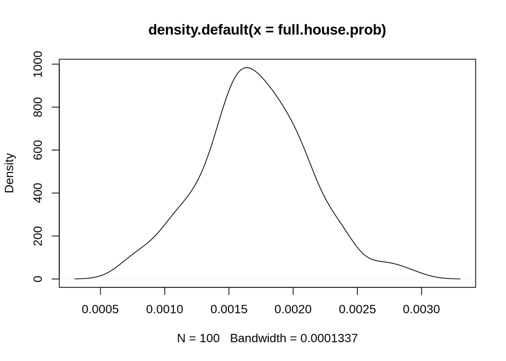

```r
for (k in 1:sims) {

    for (n in 1:sample) {

        draw <- sample(deck, 5)

        if (length(unique(draw)) == 2)
            full.house[n, k] <- 1
    }

    full.house.prob[k] <- mean(full.house[, k])
}

plot(density(full.house.prob))
```

[home](https://rsh249.github.io/applied_bioinformatics)